# Manipulando Dados

Ícaro Vidal Freire

Parte IV

[figure not shown]

## 1. A arte de manipular dados

A manipulação de dados, que inclui, dentre outras coisas, coleta, limpeza e organização dos mesmos, é [responsável por certa de 80% do tempo de análise](https://www.forbes.com/sites/gilpress/2016/03/23/data-preparation-most-time-consuming-least-enjoyable-data-science-task-survey-says/?sh=5bea714b6f63) do pesquisador. Além disso, cerca de 76% desses pesquisadores consideram a preparação dos dados como a parte menos agradável de seu trabalho.

Dito isso, usar ferramentas que mitigam tal sentimento/realidade é fundamental.

Como já falamos, existe uma variedade de pacotes para análise e manipulação de dados, inclusive tais procedimentos podem ser feitos pelo próprio `R Base`. Todavia, também descacamos que o pacote `tidyverse` tem sido um expoente, nos últimos anos, nessa tarefa.

Um integrante da família de pacotes do `tidyverse` que tangenciaremos nesse texto é o [`dplyr`](https://dplyr.tidyverse.org/). Com funções simples que realizam tarefas pequenas, juntam-se para chegar a um resultado robusto e organizado. Essa, ao meu ver, é uma das características mais persuasivas de tal pacote para manipularmos dados.

As funções do `dplyr` são inúmeras e vocês podem acessar, de forma resumida, na folha de dica (*cheat sheet*) abaixo (clique na mesma para acesso completo):

[figure not shown]

Nesse texto falaremos dos principais verbos (funções) e algumas funções auxiliares.

## 2. As principais funções

A página oficial do `dplyr` afirma que tal pacote é uma *gramática de manipulação de dados*. Como tal, fornece um conjunto de “verbos” (funções) simples que, concatenados, formam belas frases de programação um conjunto de ferramentas que auxiliam tal parte da análise de dados.

Os principais verbos, com suas descrições, são dados abaixo:

| Verbo | Descrição curta |
| --- | --- |
| [mutate()](https://dplyr.tidyverse.org/reference/mutate.html) | “modifica”/adiciona novas variáveis preservando as existentes |
| [select()](https://dplyr.tidyverse.org/reference/select.html) | “seleciona” as variáveis/colunas |
| [filter()](https://dplyr.tidyverse.org/reference/filter.html) | “filtra” casos com base em seus valores. |
| [summarise()](https://dplyr.tidyverse.org/reference/summarise.html) | “sumariza” vários valores a um único |
| [arrange()](https://dplyr.tidyverse.org/reference/arrange.html) | “arruma” a ordem das linhas |

Lembrando que as funções/verbos devem ser aplicadas em uma `tibble`.

Vamos exemplificar cada uma das funções citadas acima, bem como outras funções correlatadas.

## 3. Antes de Começar …

Trabalharemos com as funções com um conjunto de dados já utilizado por nós: `mpg`. Tal conjunto de dados faz parte do pacote `ggplot2`. Ele foi traduzido pela iniciativa [dados](https://cienciadedatos.github.io/dados/). Você pode fazer o *download* desse *dataset* em nosso repositório no GitHub: [`milhas_por_galao.csv`](https://github.com/icaro-freire/dados_csv).

São 11 variáveis e 234 observações.

```r
dados_mpg <- read_csv("dados/milhas_por_galao.csv")


dados_mpg %>% glimpse()
```

```
## Rows: 234
## Columns: 11
## $ fabricante  <chr> "audi", "audi", "audi", "audi", "audi", "audi", "audi", "a~
## $ modelo      <chr> "a4", "a4", "a4", "a4", "a4", "a4", "a4", "a4 quattro", "a~
## $ cilindrada  <dbl> 1.8, 1.8, 2.0, 2.0, 2.8, 2.8, 3.1, 1.8, 1.8, 2.0, 2.0, 2.8~
## $ ano         <dbl> 1999, 1999, 2008, 2008, 1999, 1999, 2008, 1999, 1999, 2008~
## $ cilindros   <dbl> 4, 4, 4, 4, 6, 6, 6, 4, 4, 4, 4, 6, 6, 6, 6, 6, 6, 8, 8, 8~
## $ transmissao <chr> "auto(l5)", "manual(m5)", "manual(m6)", "auto(av)", "auto(~
## $ tracao      <chr> "d", "d", "d", "d", "d", "d", "d", "4", "4", "4", "4", "4"~
## $ cidade      <dbl> 18, 21, 20, 21, 16, 18, 18, 18, 16, 20, 19, 15, 17, 17, 15~
## $ rodovia     <dbl> 29, 29, 31, 30, 26, 26, 27, 26, 25, 28, 27, 25, 25, 25, 25~
## $ combustivel <chr> "p", "p", "p", "p", "p", "p", "p", "p", "p", "p", "p", "p"~
## $ classe      <chr> "compacto", "compacto", "compacto", "compacto", "compacto"~
```

Algumas informações importantes de duas variáveis:

- **tracao**: `d` = dianteira; `t` = traseira; `4` = $4\times 4$
- **combustivel**: `p` = *premium*; `r` = regular; `e` = ethanol; `d` = diesel; `g` = gás

Eis o *dataset*

|  | fabricante | modelo | cilindrada | ano | cilindros | transmissao | tracao | cidade | rodovia | combustivel | classe |
| --- | --- | --- | --- | --- | --- | --- | --- | --- | --- | --- | --- |
| 1 | audi | a4 | 1.8 | 1999 | 4 | auto(l5) | d | 18 | 29 | p | compacto |
| 2 | audi | a4 | 1.8 | 1999 | 4 | manual(m5) | d | 21 | 29 | p | compacto |
| 3 | audi | a4 | 2 | 2008 | 4 | manual(m6) | d | 20 | 31 | p | compacto |
| 4 | audi | a4 | 2 | 2008 | 4 | auto(av) | d | 21 | 30 | p | compacto |
| 5 | audi | a4 | 2.8 | 1999 | 6 | auto(l5) | d | 16 | 26 | p | compacto |
| 6 | audi | a4 | 2.8 | 1999 | 6 | manual(m5) | d | 18 | 26 | p | compacto |
| 7 | audi | a4 | 3.1 | 2008 | 6 | auto(av) | d | 18 | 27 | p | compacto |
| 8 | audi | a4 quattro | 1.8 | 1999 | 4 | manual(m5) | 4 | 18 | 26 | p | compacto |
| 9 | audi | a4 quattro | 1.8 | 1999 | 4 | auto(l5) | 4 | 16 | 25 | p | compacto |
| 10 | audi | a4 quattro | 2 | 2008 | 4 | manual(m6) | 4 | 20 | 28 | p | compacto |

[output cut: 224 more lines]

## 4. Algo sobre a função `mutate()`

A ideia da função `mutate()` é criar uma nova coluna (variável) que esteja relacionada com outras colunas (variáveis) ou com alguma relação matemática. A ideia visual pode ser vista na figura abaixo:

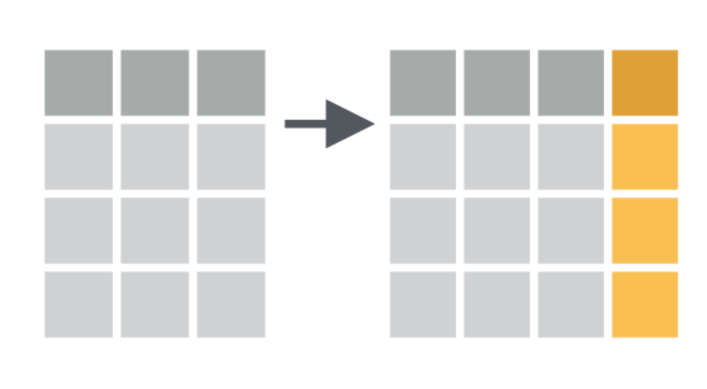

Por exemplo, em nosso *dataset*, as variáveis `cidade` e `rodovia` estão numa unidade de medida não tão usual aqui no Brasil: milhas. Sabe-se que 1 milha equivale a, aproximadamente, $1.60$ km. Então, se nosso objetivo é construir mais duas colunas em nosso *dataset*, que denominaremos `cidade_km` e `rodovia_km`, tais que seus elementos sejam os elementos das colunas `cidade` e `rodovia` multiplicados por 1.6, ou seja, `cidade_km = 1.6 * cidade` e `rodovia_km = 1.6 * rodovia`, fazemos:

```r
dados_mpg %>%
  mutate(
    cidade_km = 1.6 * cidade,
    rodovia_km = 1.6 * rodovia
  )
```

A `tibble` abaixo mostra as últimas colunas, inclusive as acrescentadas:

```
## # A tibble: 234 x 6
##    cidade rodovia combustivel classe   cidade_km rodovia_km
##     <dbl>   <dbl> <chr>       <chr>        <dbl>      <dbl>
##  1     18      29 p           compacto      28.8       46.4
##  2     21      29 p           compacto      33.6       46.4
##  3     20      31 p           compacto      32         49.6
##  4     21      30 p           compacto      33.6       48
##  5     16      26 p           compacto      25.6       41.6
##  6     18      26 p           compacto      28.8       41.6
##  7     18      27 p           compacto      28.8       43.2
##  8     18      26 p           compacto      28.8       41.6
##  9     16      25 p           compacto      25.6       40
## 10     20      28 p           compacto      32         44.8
## # ... with 224 more rows
```

### 4.1 Outras considerações

Existem algumas funções que associam-se ao `mutate()` de forma bem harmoniosa. Uma delas é a `recode()`.

Por exemplo, na variável `transmissao` existem muitas variações de, basicamente, duas categorias de marchas: *manual* ou *automática*. Como poderíamos criar uma coluna onde apareça apenas esses duas categorias? Bom, primeiro precisamos saber quais são as variações existentes em `transmissao`. Para isso, precisamos extrair somente os nomes sem repetições. A função `distinct()` faz esse processo:

```r
dados_mpg %>%
  distinct(transmissao)
```

```
## # A tibble: 10 x 1
##    transmissao
##    <chr>
##  1 auto(l5)
##  2 manual(m5)
##  3 manual(m6)
##  4 auto(av)
##  5 auto(s6)
##  6 auto(l4)
##  7 auto(l3)
##  8 auto(l6)
##  9 auto(s5)
## 10 auto(s4)
```

Temos, então, 10 variações: 2 para marcha *manual*; e, 8 para *automatica*. Vamos “recodificar” essas variações da seguinte forma:

```r
mutate(
  nova_variavel = recode(
    variavel_antiga,
    "variacao_antiga_1" = "nova_variacao_1",
    "variacao_antiga_2" = "nova_variacao_2",
    ...
  )
)
```

Mais especificamente, temos:

```r
dados_mpg %>%
  mutate(
    marchas_tipo = recode(
      transmissao,
      "auto(l5)"   = "automatica",
      "manual(m5)" = "manual",
      "manual(m6)" = "manual",
      "auto(av)"   = "automatica",
      "auto(s6)"   = "automatica",
      "auto(l4)"   = "automatica",
      "auto(l3)"   = "automatica",
      "auto(l6)"   = "automatica",
      "auto(s5)"   = "automatica",
      "auto(s4)"   = "automatica"
    )
  )
```

Veja a comparação entre as duas configurações:

```
## # A tibble: 234 x 2
##    transmissao marchas_tipo
##    <chr>       <chr>
##  1 auto(l5)    automatica
##  2 manual(m5)  manual
##  3 manual(m6)  manual
##  4 auto(av)    automatica
##  5 auto(l5)    automatica
##  6 manual(m5)  manual
##  7 auto(av)    automatica
##  8 manual(m5)  manual
##  9 auto(l5)    automatica
## 10 manual(m6)  manual
## # ... with 224 more rows
```

Existe um pacote do `tidyverse`, a saber, `stringr`, que pode dar uma outra solução para esse problema, mas não será objeto de estudo em nosso curso.

## 5. Algo sobre a função `select()`

Muitas vezes não precisamos de todas as variáveis de um *dataset*. Selecionar colunas é um processo habitual e muito simples com o `dplyr`. Basta usarmos a função `select()`.

A ideia visual é dada a seguir:

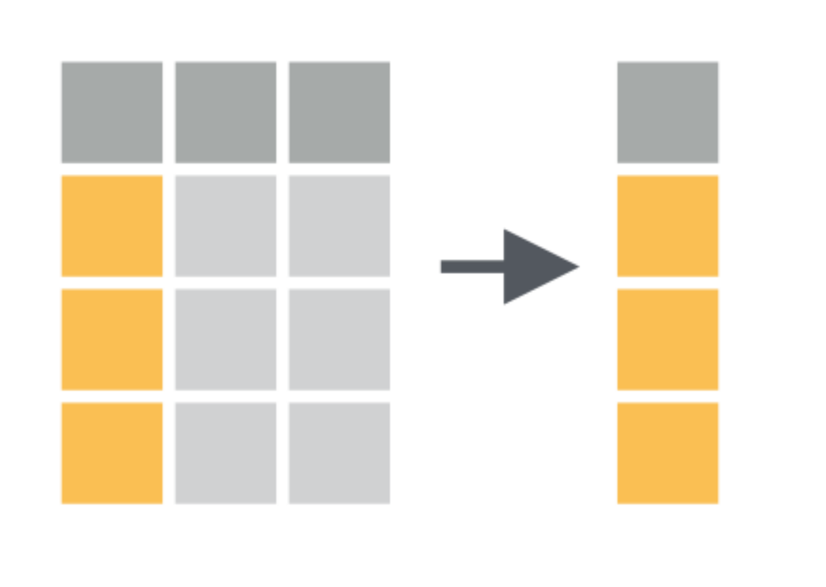

Existem muitas formas de seleção de variáveis, mas vamos listar apenas algumas delas.

### 5.1 Selecionar apenas uma coluna

Usamos a estrutura:

```r
dados %>%
  select(variavel_desejada)
```

Assim, se quisermos selecionar a variável `cilindros`, fazemos:

```r
dados_mpg %>%
  select(cilindros)
```

```
## # A tibble: 234 x 1
##    cilindros
##        <dbl>
##  1         4
##  2         4
##  3         4
##  4         4
##  5         6
##  6         6
##  7         6
##  8         4
##  9         4
## 10         4
## # ... with 224 more rows
```

Caso, nosso objetivo seja **não** selecionar a variável `cilindros`, usamos o operador de negação antes da palavra ou o sinal de menos:

```r
dados_mpg %>%
  select(!cilindros) # ou select(-cilindros)
```

### 5.2 Selecionar mais de uma variável

Podemos separar por vírgulas

```r
dados_mpg %>%
  select(fabricante, modelo, cilindrada, ano)
```

```
## # A tibble: 234 x 4
##    fabricante modelo     cilindrada   ano
##    <chr>      <chr>           <dbl> <dbl>
##  1 audi       a4                1.8  1999
##  2 audi       a4                1.8  1999
##  3 audi       a4                2    2008
##  4 audi       a4                2    2008
##  5 audi       a4                2.8  1999
##  6 audi       a4                2.8  1999
##  7 audi       a4                3.1  2008
##  8 audi       a4 quattro        1.8  1999
##  9 audi       a4 quattro        1.8  1999
## 10 audi       a4 quattro        2    2008
## # ... with 224 more rows
```

Ou, podemos uasar `a:b`, onde `a` é a primeira variável e `b` a última, em sequência.

```r
dados_mpg %>%
  select(fabricante:ano)
```

```
## # A tibble: 234 x 4
##    fabricante modelo     cilindrada   ano
##    <chr>      <chr>           <dbl> <dbl>
##  1 audi       a4                1.8  1999
##  2 audi       a4                1.8  1999
##  3 audi       a4                2    2008
##  4 audi       a4                2    2008
##  5 audi       a4                2.8  1999
##  6 audi       a4                2.8  1999
##  7 audi       a4                3.1  2008
##  8 audi       a4 quattro        1.8  1999
##  9 audi       a4 quattro        1.8  1999
## 10 audi       a4 quattro        2    2008
## # ... with 224 more rows
```

Também podemos usar a mesma ideia anterior, mas usando o número relacionado a posição da coluna. Por exemplo, se quero selecionar da variável “fabricante” até “ano”, podemos fazer

```r
dados_mpg %>%
  select(1:4)
```

### 5.3 Misturando as coisas

Obviamente, podemos misturar essas seleções:

```r
dados_mpg %>%
  select(fabricante:cilindrada, transmissao, 9:11)
```

```
## # A tibble: 234 x 7
##    fabricante modelo     cilindrada transmissao rodovia combustivel classe
##    <chr>      <chr>           <dbl> <chr>         <dbl> <chr>       <chr>
##  1 audi       a4                1.8 auto(l5)         29 p           compacto
##  2 audi       a4                1.8 manual(m5)       29 p           compacto
##  3 audi       a4                2   manual(m6)       31 p           compacto
##  4 audi       a4                2   auto(av)         30 p           compacto
##  5 audi       a4                2.8 auto(l5)         26 p           compacto
##  6 audi       a4                2.8 manual(m5)       26 p           compacto
##  7 audi       a4                3.1 auto(av)         27 p           compacto
##  8 audi       a4 quattro        1.8 manual(m5)       26 p           compacto
##  9 audi       a4 quattro        1.8 auto(l5)         25 p           compacto
## 10 audi       a4 quattro        2   manual(m6)       28 p           compacto
## # ... with 224 more rows
```

Nunca se esqueça: escolha a forma de seleção pensando na reprodutibilidade, se seu objetivo é compartilhar os dados ou resultados. Logo, nem sempre é aconselhável selecionar variáveis pelos respectivos números de suas posições, visto que pode haver muitas variáveis em um *dataset*. Sempre que possível, selecione pelo nome das variáveis.

## 6. Algo sobre a função `filter()`

Certamente existem muitas informações espalhadas pelas observações de um *dataset*. Filtrar aquelas que desejamos é essencial em uma análise de dados.

Para isso, usaremos a função `filter()`.

A ideia visual é a seguinte:

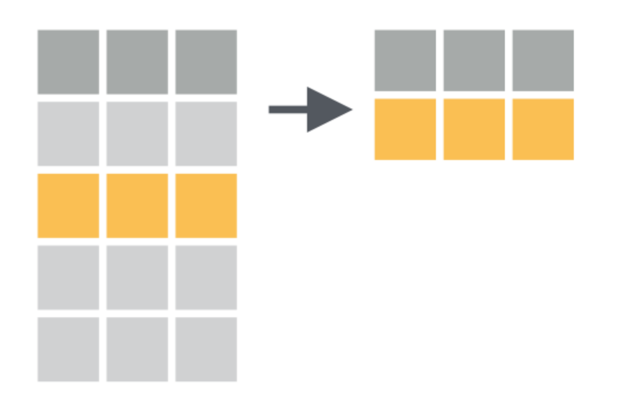

Assim, por exemplo, suponha que no *dataset* que estamos usando, seja nosso objetivo filtrar os carros da *toyota* que possuam número de cilindradas maior do que 3. Para isso, usamos:

```r
dados_mpg %>%
  filter(fabricante == "toyota" & cilindrada > 3)
```

```
## # A tibble: 12 x 11
##    fabricante modelo        cilindrada   ano cilindros transmissao tracao cidade
##    <chr>      <chr>              <dbl> <dbl>     <dbl> <chr>       <chr>   <dbl>
##  1 toyota     4runner 4wd          3.4  1999         6 auto(l4)    4          15
##  2 toyota     4runner 4wd          3.4  1999         6 manual(m5)  4          15
##  3 toyota     4runner 4wd          4    2008         6 auto(l5)    4          16
##  4 toyota     4runner 4wd          4.7  2008         8 auto(l5)    4          14
##  5 toyota     camry                3.5  2008         6 auto(s6)    d          19
##  6 toyota     camry solara         3.3  2008         6 auto(s5)    d          18
##  7 toyota     land cruiser~        4.7  1999         8 auto(l4)    4          11
##  8 toyota     land cruiser~        5.7  2008         8 auto(s6)    4          13
##  9 toyota     toyota tacom~        3.4  1999         6 manual(m5)  4          15
## 10 toyota     toyota tacom~        3.4  1999         6 auto(l4)    4          15
## 11 toyota     toyota tacom~        4    2008         6 manual(m6)  4          15
## 12 toyota     toyota tacom~        4    2008         6 auto(l5)    4          16
## # ... with 3 more variables: rodovia <dbl>, combustivel <chr>, classe <chr>
```

Há, também, uma outra forma para selecionar linhas em um *dataset*, relacionando apenas a posicão das observações. Por exemplo, se quisermos, por algum motivo, selecionar as 5 primeiras linhas de nosso conjunto de dados; usamos a função `slice(1:5)`:

```r
dados_mpg %>%
  slice(1:5)
```

```
## # A tibble: 5 x 11
##   fabricante modelo cilindrada   ano cilindros transmissao tracao cidade rodovia
##   <chr>      <chr>       <dbl> <dbl>     <dbl> <chr>       <chr>   <dbl>   <dbl>
## 1 audi       a4            1.8  1999         4 auto(l5)    d          18      29
## 2 audi       a4            1.8  1999         4 manual(m5)  d          21      29
## 3 audi       a4            2    2008         4 manual(m6)  d          20      31
## 4 audi       a4            2    2008         4 auto(av)    d          21      30
## 5 audi       a4            2.8  1999         6 auto(l5)    d          16      26
## # ... with 2 more variables: combustivel <chr>, classe <chr>
```

## 7. Algo sobre a função `summarise()`

Muitas vezes, na análise exploratória dos dados, queremos quantificar algumas variáveis: saber a média; mediana; desvio padrão; coeficiente de correlação; frequência absoluta, relativa ou acumulada; etc. A função `summarise()` faz isso: resume (sumariza) uma certa quantidade de dados em uma única informação desejada (para cada quantificação).

A ideia visual é a seguinte:

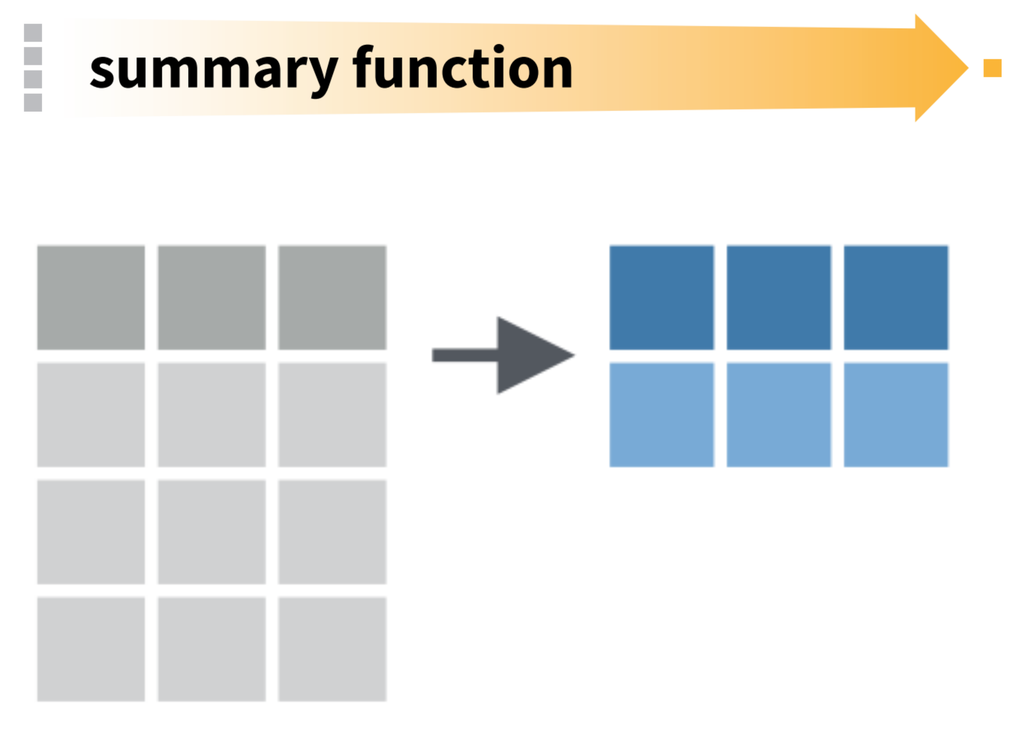

Suponha, agora, que nosso objetivo seja saber a média de milhas por galão de combustível, na cidade, de todos os carros juntos. Ou seja, desejo sumarisar a coluna `cidade`.

```r
dados_mpg %>%
  summarise(
    media_total_cidade = mean(cidade)
  )
```

```
## # A tibble: 1 x 1
##   media_total_cidade
##                <dbl>
## 1               16.9
```

Ou, se quisermos inserir, também, a média total da rodivia:

```r
dados_mpg %>%
  summarise(
    media_total_cidade = mean(cidade),
    media_total_rodovia = mean(rodovia)
  )
```

```
## # A tibble: 1 x 2
##   media_total_cidade media_total_rodovia
##                <dbl>               <dbl>
## 1               16.9                23.4
```

Obviamente, o mesmo raciocínio pode ser aplicado com diversas outras funções estatísticas. Abaixo segue a sumarização da variável cidade com diversas medidas estatísticas:

```r
dados_mpg %>%
  summarise(
    media_cidade = mean(cidade),      # mean(): média aritmética
    mediana_cidade = median(cidade),  # median(): mediana
    dp_cidade = sd(cidade),           # sd(): desvio padrão
    max_cidade = max(cidade),         # max(): maior valor
    min_cidade = min(cidade)          # min(): menor valor
  )
```

```
## # A tibble: 1 x 5
##   media_cidade mediana_cidade dp_cidade max_cidade min_cidade
##          <dbl>          <dbl>     <dbl>      <dbl>      <dbl>
## 1         16.9             17      4.26         35          9
```

Bom … saber o maior valor (ou menor) para a variável `cidade` tem relevância estatística, mas alguns dos cálculos acima possuem esse sentido? O que significa “média total das milhas percorridas por todos os carros na cidade”? Afinal, existem diferentes marcas, diferentes características, etc., como podemos calcular uma média tão geral assim?

Se quisermos a média, na cidade, para os carros da fabricante `chevrolet`, por exemplo, teria mais relevância estatística. Para fazermos isso, precisamos usar a função `filter()` para filtrarmos os carros da chevrolet e, em seguida, sumarizar. Tudo isso, usando o `pipe` (`%>%`) para interligá-los.

```r
dados_mpg %>%
  filter(fabricante == "chevrolet") %>%  # filtra os carros da chevrolet
  summarise(media_cidade = mean(cidade)) # sumariza com a média
```

```
## # A tibble: 1 x 1
##   media_cidade
##          <dbl>
## 1           15
```

Portanto, a média dos carros da chevrolet, na cidade, é de 15 milhas por galão de combustível.

Mas, e se quiséssemos saber a média, na cidade, dos carros da chevrolet, usando o combustível `r` (regular)? Simples: filtramos também essa característica.

```r
dados_mpg %>%
  filter(fabricante == "chevrolet" & combustivel == "r") %>%
  summarise(media_gasolina = mean(cidade))
```

```
## # A tibble: 1 x 1
##   media_gasolina
##            <dbl>
## 1           15.6
```

Portanto, os carros da chevrolet, na cidade, que usam combustível regular, apresentam média de 15.6 milhas por galão de combustível.

Mas, obviamente, quando há grupos envolvidos, é natural compararmos entre eles alguma característica. Por exemplo, como seria a média, na cidade, dos diferentes fabricantes dos carros?

Para isso, precisamos da função `group_by()`.

### 7.1 A relevante `group_by()`

A ideia visual é a seguinte:

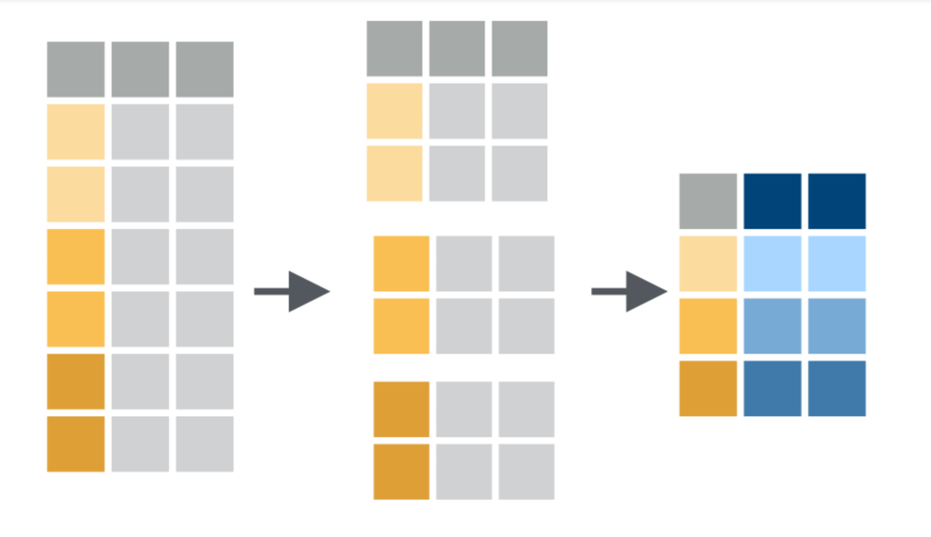

Ou seja, ela separa as categorias em cada observação semelhante, agrupando-as adequadamente.

Assim, se nosso objetivo é comparar a média na cidade para as diferentes marcas/fabricantes, vamos agrupar nosso *dataset* pelos fabricantes e, em seguida, calcular a média.

```r
dados_mpg %>%
  group_by(fabricante) %>%
  summarise(media_cidade = mean(cidade))
```

```
## # A tibble: 15 x 2
##    fabricante media_cidade
##    <chr>             <dbl>
##  1 audi               17.6
##  2 chevrolet          15
##  3 dodge              13.1
##  4 ford               14
##  5 honda              24.4
##  6 hyundai            18.6
##  7 jeep               13.5
##  8 land rover         11.5
##  9 lincoln            11.3
## 10 mercury            13.2
## 11 nissan             18.1
## 12 pontiac            17
## 13 subaru             19.3
## 14 toyota             18.5
## 15 volkswagen         20.9
```

E assim podemos comparar melhor as coisas.

Entretanto, seria muito bom ordenar a média na cidade em ordem crescente ou decrescente, não? Para isso, usamos a função `arrange()`.

### 7.1.1 Distribuição de Frequência

Antes, porém, vamos aplicar a ideia de agrupamento para fazermos uma tabela de frequência.

```r
milhas %>%
  group_by(combustivel) %>%
  select(combustivel) %>%
  summarise(
    n = n(),             # frequência absoluta
    f = (n / 234) * 100  # frequência relativa
  )
```

```
## # A tibble: 5 x 3
##   combustivel     n      f
##   <chr>       <int>  <dbl>
## 1 d               5  2.14
## 2 e               8  3.42
## 3 g               1  0.427
## 4 p              52 22.2
## 5 r             168 71.8
```

#### 7.1.2 Sem agrupamentos

Uma outra forma, sem precisar usar a função `summarise()` ou agrupamentos

```r
milhas %>%
  count(combustivel)
```

```
## # A tibble: 5 x 2
##   combustivel     n
##   <chr>       <int>
## 1 d               5
## 2 e               8
## 3 g               1
## 4 p              52
## 5 r             168
```

## 8. Algo sobre a função `arrange()`

A ideia visual é a seguinte:

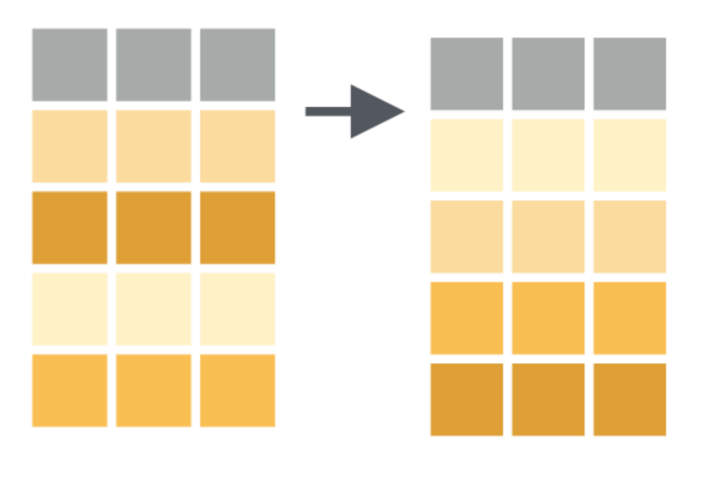

Observe que a ordenação foi do “tom” mais claro para o mais escuro. Numericamente, a ordenação, por padrão, é do menor para o maior valor.

Vejamos como ordenamos a média da cidade para cada fabricante:

```r
dados_mpg %>%
  group_by(fabricante) %>%
  summarise(media_cidade = mean(cidade)) %>%
  arrange(media_cidade) # note a variável dentro do argumento da função
```

```
## # A tibble: 15 x 2
##    fabricante media_cidade
##    <chr>             <dbl>
##  1 lincoln            11.3
##  2 land rover         11.5
##  3 dodge              13.1
##  4 mercury            13.2
##  5 jeep               13.5
##  6 ford               14
##  7 chevrolet          15
##  8 pontiac            17
##  9 audi               17.6
## 10 nissan             18.1
## 11 toyota             18.5
## 12 hyundai            18.6
## 13 subaru             19.3
## 14 volkswagen         20.9
## 15 honda              24.4
```

Entretanto, como nosso objetivo é verficar a média de milhas por galão na cidade, interessa-nos aqueles frabricantes, cujos carros possuam a maior média. Então, a ordenação de forma decrescente é a mais adequada para esse nosso exemplo. Usamos para isso o argumento `desc()`:

```r
dados_mpg %>%
  group_by(fabricante) %>%
  summarise(media_cidade = mean(cidade)) %>%
  arrange(desc(media_cidade))
```

```
## # A tibble: 15 x 2
##    fabricante media_cidade
##    <chr>             <dbl>
##  1 honda              24.4
##  2 volkswagen         20.9
##  3 subaru             19.3
##  4 hyundai            18.6
##  5 toyota             18.5
##  6 nissan             18.1
##  7 audi               17.6
##  8 pontiac            17
##  9 chevrolet          15
## 10 ford               14
## 11 jeep               13.5
## 12 mercury            13.2
## 13 dodge              13.1
## 14 land rover         11.5
## 15 lincoln            11.3
```

Com isso, concluímos que a fabricante que possui maior média de milhas por galão de combustível é a `honda`.

Tudo bem … essa informação nos diz que os carros da honda produzem uma média de milhas por galão maior do que os outros envolvidos. Mas, e se eu quisesse saber, qual **o** carro que possui a maior média de milhas por galão e de qual fabricante ele é? Nesse caso, sequer é necessário agrupamentos! Basta selecionarmos o modelo e a milha na cidade de forma decrescente.

```r
dados_mpg %>%
  select(modelo, cidade) %>%
  arrange(desc(cidade))
```

```
## # A tibble: 234 x 2
##    modelo     cidade
##    <chr>       <dbl>
##  1 new beetle     35
##  2 jetta          33
##  3 new beetle     29
##  4 civic          28
##  5 corolla        28
##  6 civic          26
##  7 corolla        26
##  8 corolla        26
##  9 civic          25
## 10 civic          25
## # ... with 224 more rows
```

Então, o carro que anda mais milhas por galão na cidade é o *new beetle*: 35 milhas por galão de combustível.

Ah … se quisermos apenas os $n$ primeitos carros, podemos usar a função `top_n()`. Por exemplo, os cinco primeiros carros que andam mais milhas por galão de combustível na cidade é:

```r
dados_mpg %>%
  select(modelo, cidade) %>%
  arrange(desc(cidade)) %>%
  top_n(5)                    # seleciona os cinco maiores
```

```
## # A tibble: 5 x 2
##   modelo     cidade
##   <chr>       <dbl>
## 1 new beetle     35
## 2 jetta          33
## 3 new beetle     29
## 4 civic          28
## 5 corolla        28
```

Observe que aparece duas vezes o carro *new beetle*. Provavelmente, existe uma característica diferente nos modelos. Carros automáticos e manuais costumam apresentar diferenças relevantes em milhas percorridas por galão. Para verificarmos isso, fazemos:

```r
dados_mpg %>%
  select(modelo, transmissao, cidade) %>%
  arrange(desc(cidade)) %>%
  top_n(5)
```

```
## # A tibble: 5 x 3
##   modelo     transmissao cidade
##   <chr>      <chr>        <dbl>
## 1 new beetle manual(m5)      35
## 2 jetta      manual(m5)      33
## 3 new beetle auto(l4)        29
## 4 civic      manual(m5)      28
## 5 corolla    manual(m5)      28
```

O que mostra que o carro com transmissão manual *new beetle* é o que percorre mais milha por galão, embora o *new beettle* com transmissão automática também alcança uma boa posição: terceiro lugar.

## Considerações finais

Lembrem-se que esse é um texto introdutório, só aprenderemos a manipular, limpar e organizar os dados, praticando.

E, obviamente, o pacoter `dplyr` não é usado sozinho.

Mas, ficamos impressionados com os aspectos quantitativos que podemos extrair dos nossos *datasets*. Todavia, nem sempre aspectos númericos são suficientes para uma boa intrerpretação estatística.

Para mostrarmos a afirmação do parágrafo anterior, consideremos um *dataset* especial, construído artificialmente pelo estatístico Francis Anscombe. Esse conjunto de dados é conhecido por [Quarteto de Anscombe](https://pt.wikipedia.org/wiki/Quarteto_de_Anscombe).

```r
dados_enganosos <- read_csv("dados/quarteto_de_anscombe.csv")

dados_enganosos
```

```
## # A tibble: 44 x 3
##    dados     x     y
##    <chr> <dbl> <dbl>
##  1 I        10  8.04
##  2 I         8  6.95
##  3 I        13  7.58
##  4 I         9  8.81
##  5 I        11  8.33
##  6 I        14  9.96
##  7 I         6  7.24
##  8 I         4  4.26
##  9 I        12 10.8
## 10 I         7  4.82
## # ... with 34 more rows
```

Temos, então, quatro conjuntos de dados (I, II, III, e IV), com 11 observações numéricas em cada um deles, totalizando 44 observações. Vamos sumarizar as variáveis numéricas com algumas estatísticas conhecidas[^1]:

```r
dados_enganosos %>%
  group_by(dados) %>%
  summarise(
    media_x = mean(x),
    dp_x = sd(x),
    media_y = mean(y),
    dp_y = sd(y),
    r_pearson = round(cor(x, y), 2)
  )
```

```
## # A tibble: 4 x 6
##   dados media_x  dp_x media_y  dp_y r_pearson
##   <chr>   <dbl> <dbl>   <dbl> <dbl>     <dbl>
## 1 I           9  3.32    7.50  2.03      0.82
## 2 II          9  3.32    7.50  2.03      0.82
## 3 III         9  3.32    7.5   2.03      0.82
## 4 IV          9  3.32    7.50  2.03      0.82
```

Vejam que, para cada grupo de dados, tanto para $x$ quanto para $y$: a média é a mesma; o desvio padrão é o mesmo; e, o coeficiente de correlação de Pearson também é o mesmo. Mas, será que esses dados são tão semelhantes assim?

Esse conjunto de dados nos mostra a relevância de uma outra parte da analise de dados, absolutamente necessária: a visualização dos dados.

E, para isso, usaremos o pacote `ggplot2`.

[output not shown]

[^1]: Caso você não conheça o Coeficiente de Correlação de Pearson, veja [aqui](https://pt.wikipedia.org/wiki/Coeficiente_de_correla%C3%A7%C3%A3o_de_Pearson)